# Covid-19 - SMSD

#### Goal

Build up a useful model in order to predict response variable Y starting from data provided.

- response variable: number of new positives
- data: Covid-19 spreading outbreak from the official website of Protezione Civile

#### Dataset

Load dataset.

#### Clean dataset

Read data we are interested in, then those that are relative to the following couple of parameters:

- regione: Sicilia
- data: 1st October 2020 to 1st February 2021

#### Perform some explanatory analysis for your data.

See how response variable changes over time:

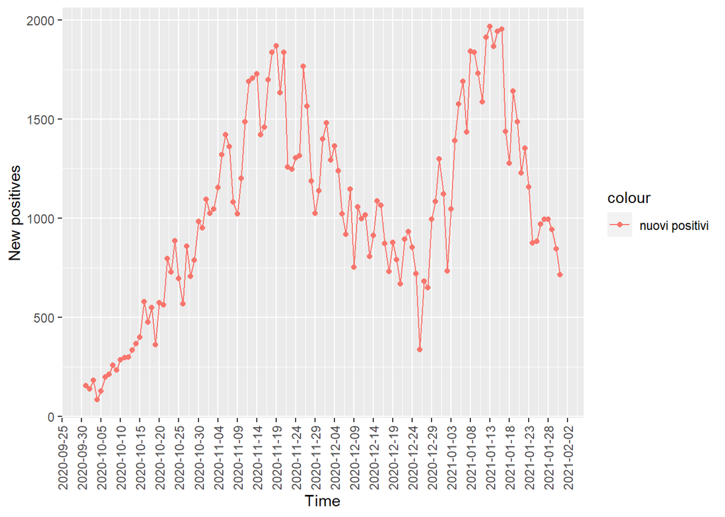

See how response variable changes wrt explanatory variables provided

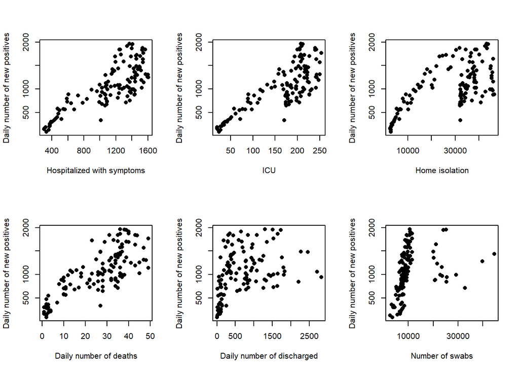

See how response variable changes wrt covariates considered

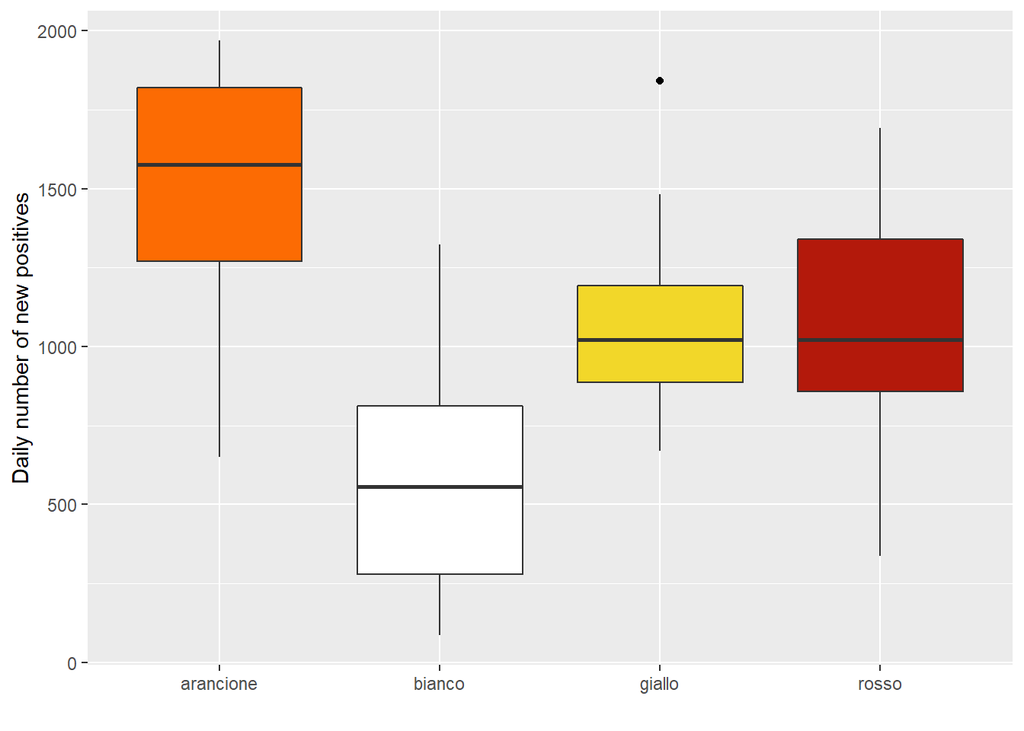

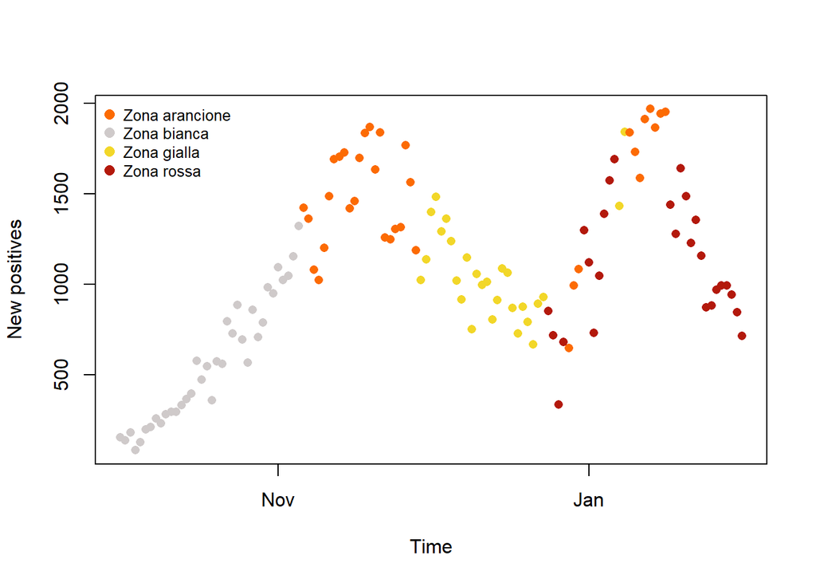

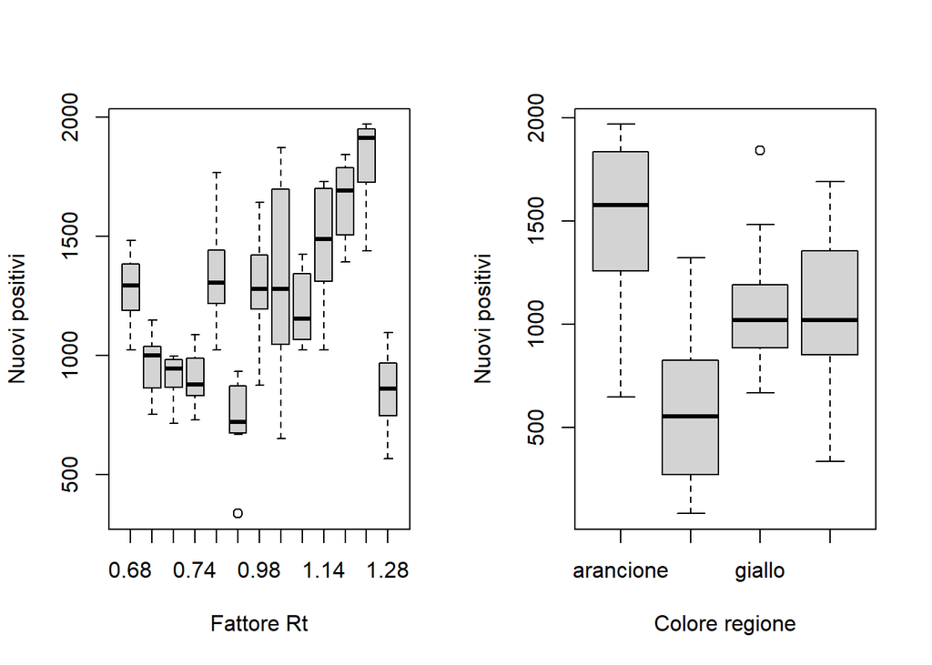

How swabs and new positives change over time:

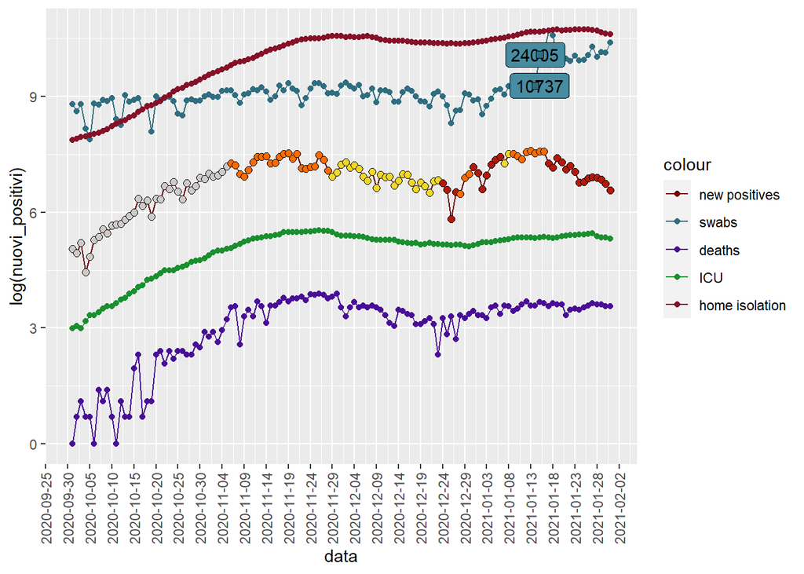

##### Describe the quality of the data and discuss whether and how a plausible statistical model could be posed.

Check for missing values in the data frame

```
##                              na_count
## data                                0
## ricoverati_con_sintomi              0
## terapia_intensiva                   0
## totale_ospedalizzati                0
## isolamento_domiciliare              0
## totale_positivi                     0
## variazione_totale_positivi          0
## nuovi_positivi                      0
## dimessi_guariti                     0
## deceduti                            0
## casi_da_sospetto_diagnostico       59
## casi_da_screening                  59
## totale_casi                         0
## tamponi                             0
## casi_testati                        0
## ingressi_terapia_intensiva         63
## nuovi_tamponi                       0
## nuovi_decessi                       0
## nuovi_dimessi                       0
## color                               0
## Rt                                 25
```

Understand how each potential predictor relates to the outcome but also to every other predictor.

We observe the following variables: - number of hospedalized with symptoms - number of ICU - number of deaths - number of swabs

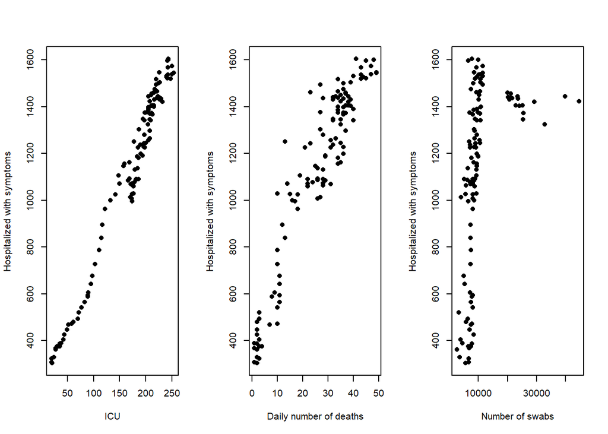

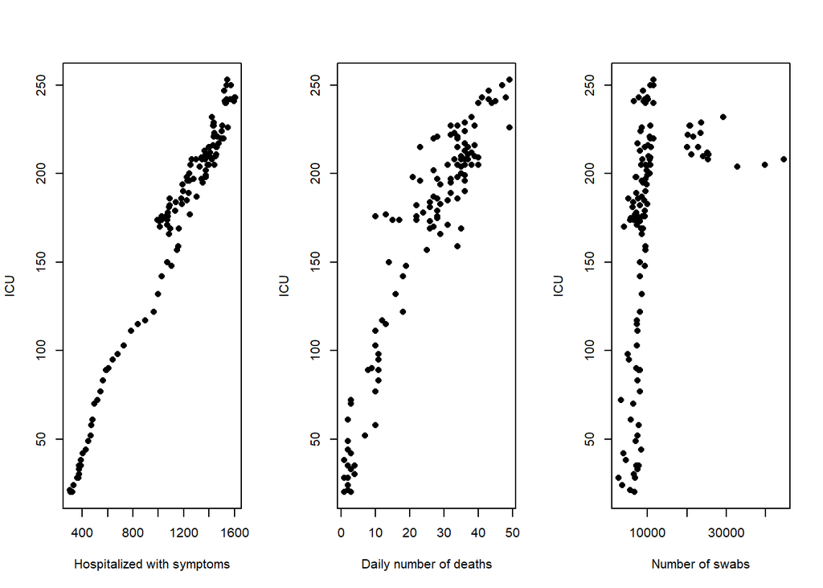

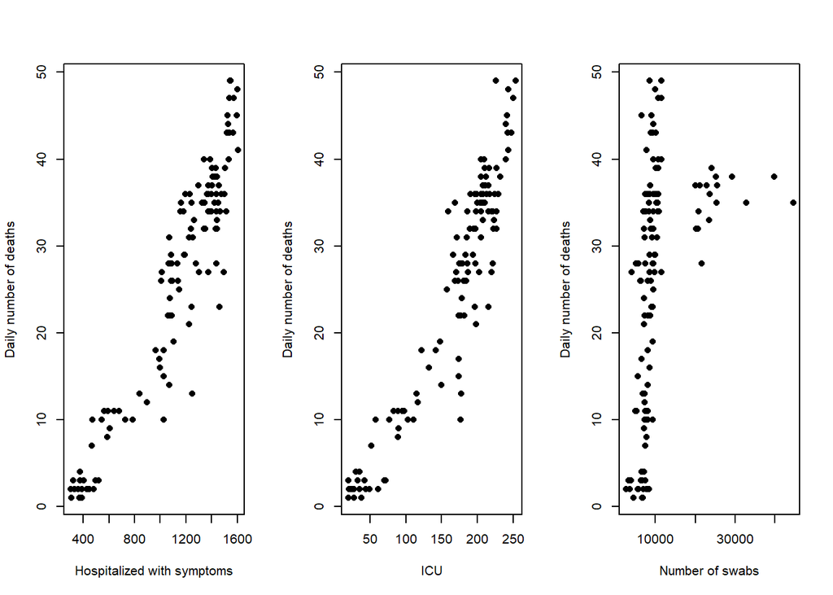

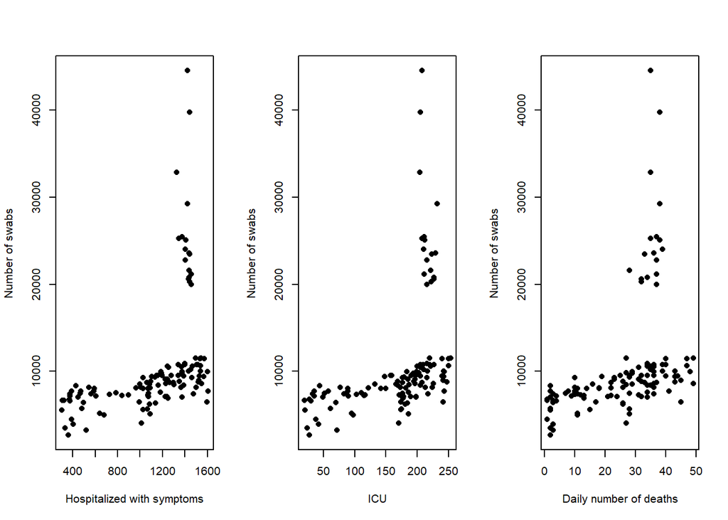

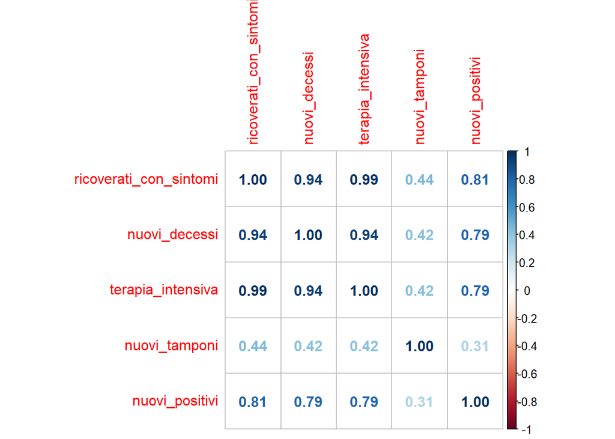

There are some values for the number of swabs carried out which seem to be not useful and misleading. By considering just the days in which the number of swabs was less than 20000, we are still managing the 86,17% of the data, but we can see how the correlation between the number of new positives and the number of swabs carried out completely changes. The following scatterplots show the correlation between the number of swabs and the other variables considered, while the one below show the correlation between the number of swabs and our response variable.

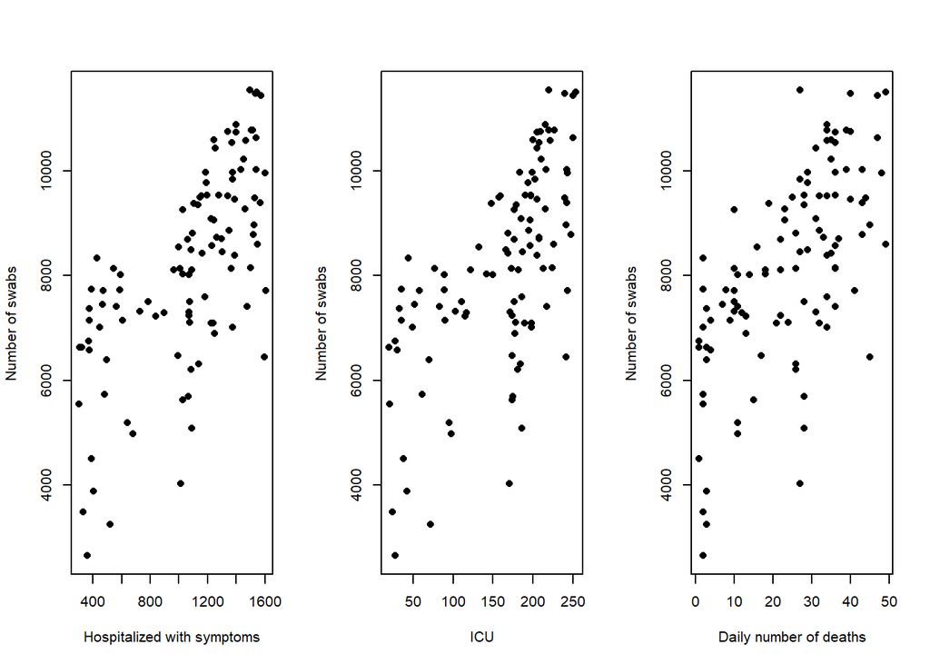

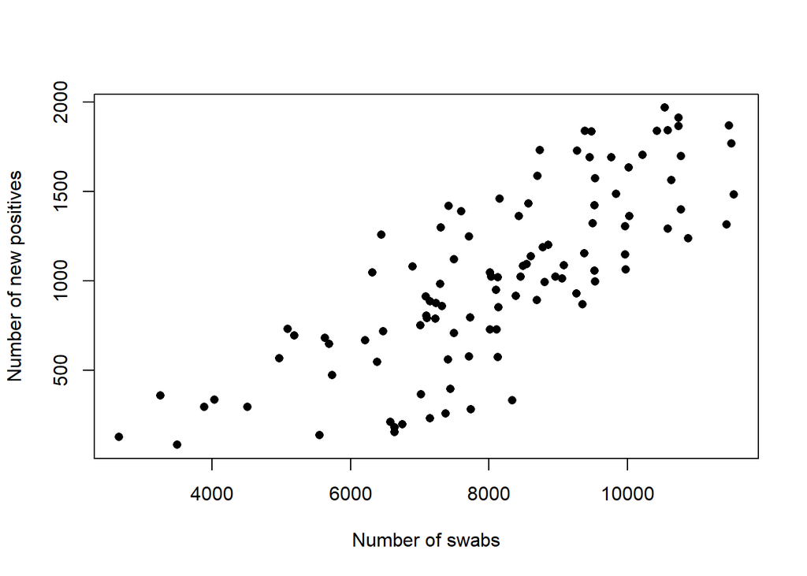

Now the correlation between the number of swabs and the response variable seems to be completely different:

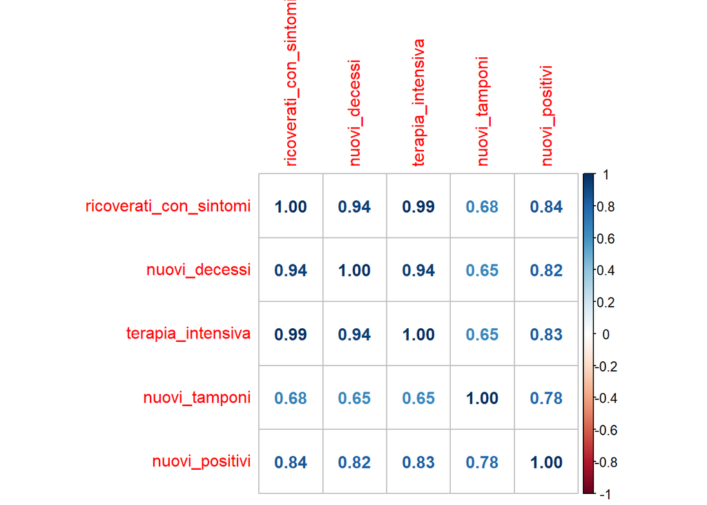

#### Building models

Then we start exploring the previous correlation, since the number of swabs carried out is one of the main factor which determines the number of new positives. Indeed, the number of positives is strictly contained in the interval [0, n. of swabs].

```
##
## Call:
## lm(formula = nuovi_positivi ~ nuovi_tamponi, data = new_df)
##
## Residuals:
##     Min      1Q  Median      3Q     Max
## -733.11 -219.45   11.83  251.43  585.68
##
## Coefficients:
##                 Estimate Std. Error t value Pr(>|t|)
## (Intercept)   -622.13629  133.86495  -4.647 9.89e-06 ***
## nuovi_tamponi    0.20255    0.01607  12.607  < 2e-16 ***
## ---
## Signif. codes:  0 '***' 0.001 '**' 0.01 '*' 0.05 '.' 0.1 ' ' 1
##
## Residual standard error: 313 on 104 degrees of freedom
## Multiple R-squared:  0.6045, Adjusted R-squared:  0.6007
## F-statistic: 158.9 on 1 and 104 DF,  p-value: < 2.2e-16
```

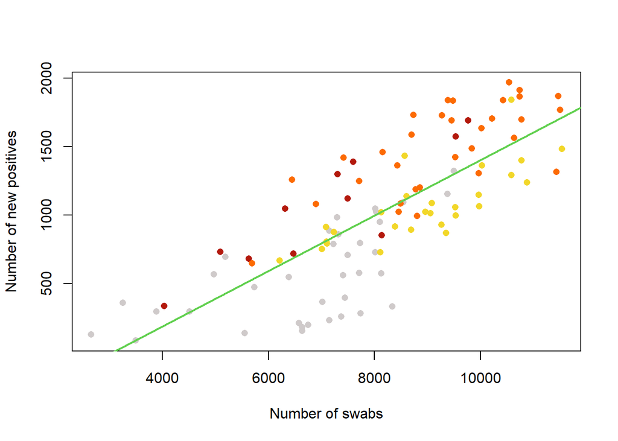

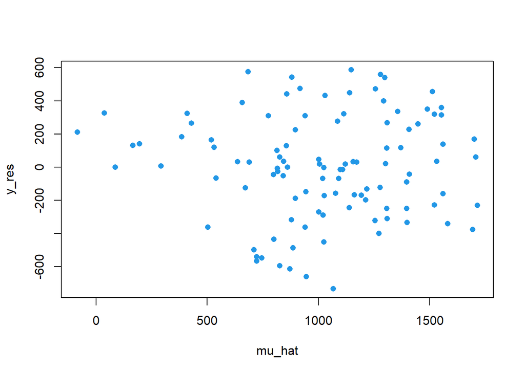

```
##
## Call:
## lm(formula = nuovi_positivi ~ nuovi_tamponi + restr, data = new_df)
##
## Residuals:
##     Min      1Q  Median      3Q     Max
## -554.33 -156.33   31.17  181.34  562.59
##
## Coefficients:
##                Estimate Std. Error t value Pr(>|t|)
## (Intercept)   -563.2032   102.4385  -5.498 2.81e-07 ***
## nuovi_tamponi    0.1740     0.0127  13.705  < 2e-16 ***
## restryes       424.8859    48.9370   8.682 6.20e-14 ***
## ---
## Signif. codes:  0 '***' 0.001 '**' 0.01 '*' 0.05 '.' 0.1 ' ' 1
##
## Residual standard error: 239 on 103 degrees of freedom
## Multiple R-squared:  0.7716, Adjusted R-squared:  0.7672
## F-statistic:   174 on 2 and 103 DF,  p-value: < 2.2e-16
```

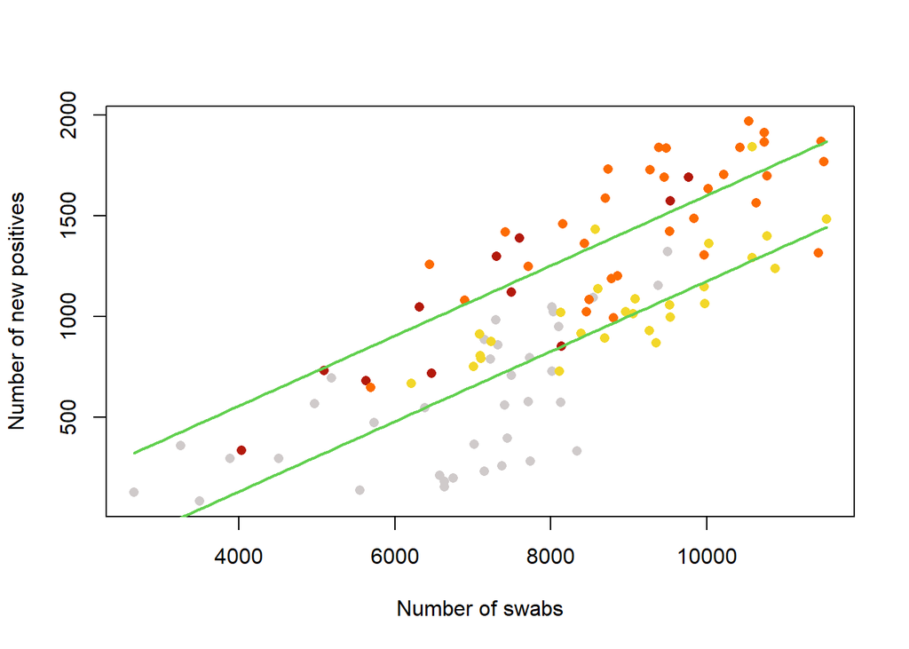

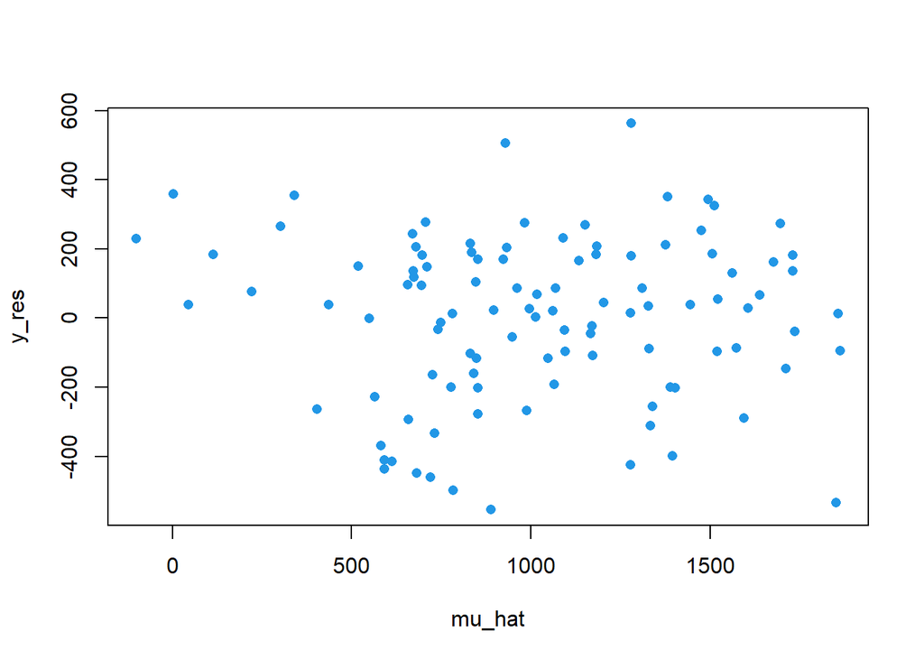

Residuals seem to be slightly better. Third model which considers interaction term

```
##
## Call:
## lm(formula = nuovi_positivi ~ nuovi_tamponi * restr, data = new_df)
##
## Residuals:
##     Min      1Q  Median      3Q     Max
## -559.57 -156.09   33.27  177.27  579.34
##
## Coefficients:
##                          Estimate Std. Error t value Pr(>|t|)
## (Intercept)            -518.31937  129.14869  -4.013 0.000114 ***
## nuovi_tamponi             0.16822    0.01629  10.330  < 2e-16 ***
## restryes                300.04615  223.00795   1.345 0.181463
## nuovi_tamponi:restryes    0.01500    0.02615   0.574 0.567312
## ---
## Signif. codes:  0 '***' 0.001 '**' 0.01 '*' 0.05 '.' 0.1 ' ' 1
##
## Residual standard error: 239.8 on 102 degrees of freedom
## Multiple R-squared:  0.7724, Adjusted R-squared:  0.7657
## F-statistic: 115.4 on 3 and 102 DF,  p-value: < 2.2e-16
```

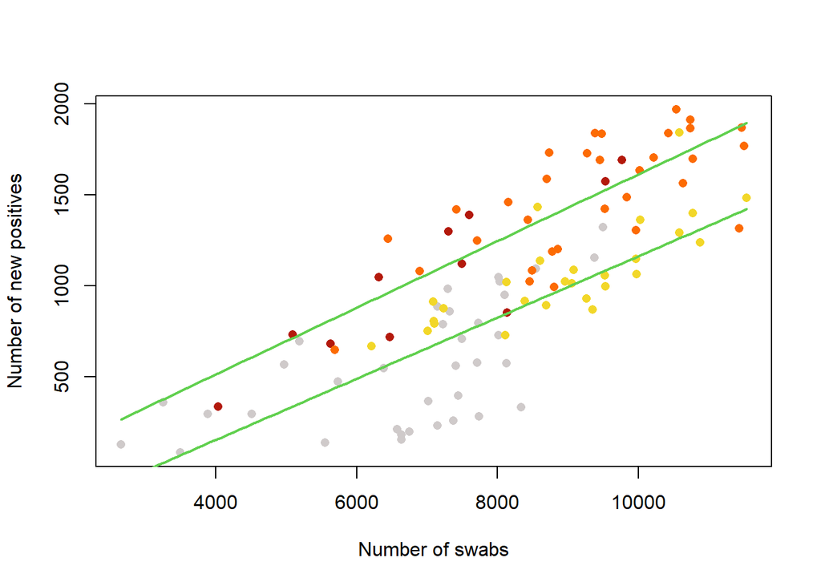

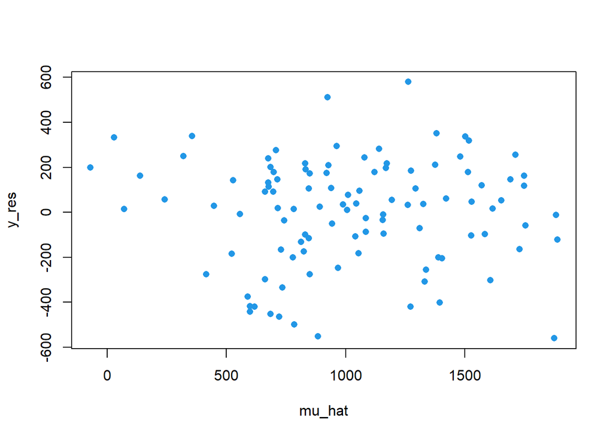

```
##
## Call:
## lm(formula = nuovi_positivi ~ nuovi_tamponi + color, data = new_df)
##
## Residuals:
##     Min      1Q  Median      3Q     Max
## -502.23 -157.76   13.72  180.90  525.96
##
## Coefficients:
##                 Estimate Std. Error t value Pr(>|t|)
## (Intercept)     83.21607  145.06552   0.574    0.567
## nuovi_tamponi    0.15184    0.01499  10.131  < 2e-16 ***
## colorbianco   -550.61105   67.80822  -8.120 1.18e-12 ***
## colorgiallo   -374.73496   61.08640  -6.135 1.68e-08 ***
## colorrosso    -110.35852   88.09536  -1.253    0.213
## ---
## Signif. codes:  0 '***' 0.001 '**' 0.01 '*' 0.05 '.' 0.1 ' ' 1
##
## Residual standard error: 232.9 on 101 degrees of freedom
## Multiple R-squared:  0.7872, Adjusted R-squared:  0.7788
## F-statistic: 93.43 on 4 and 101 DF,  p-value: < 2.2e-16
```

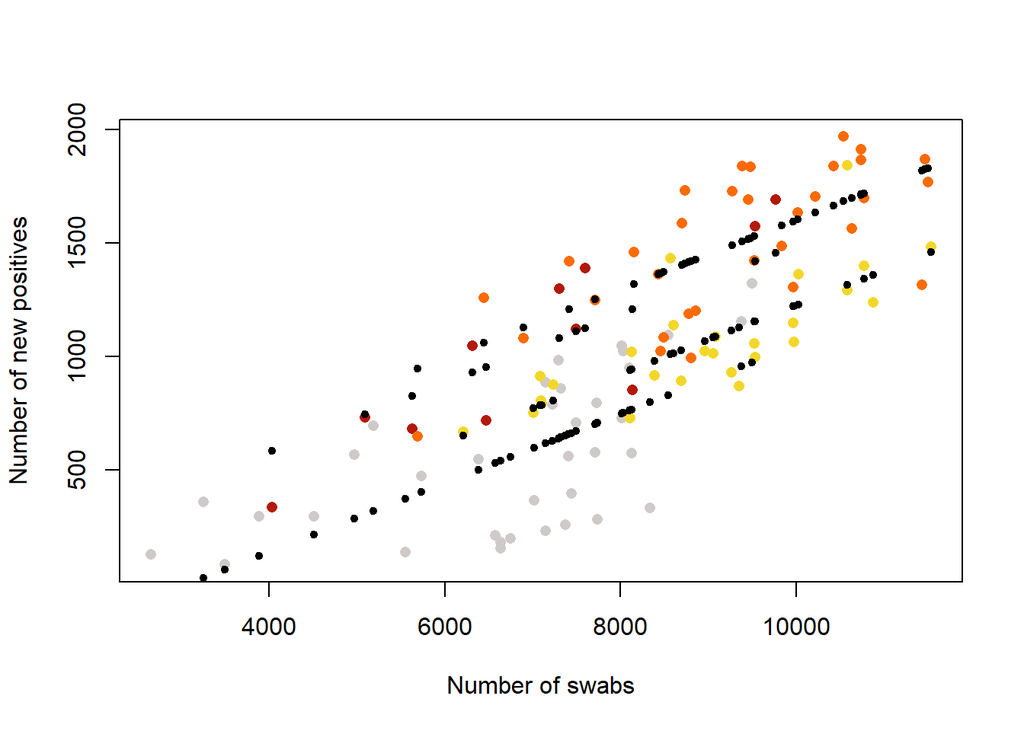

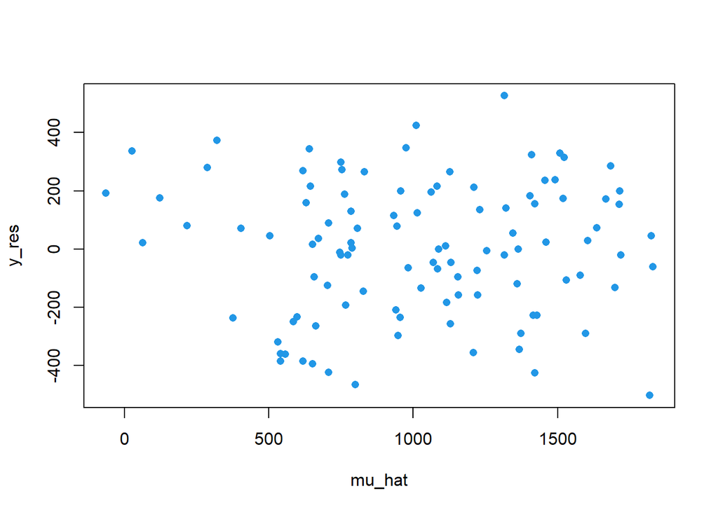

Now we order and see how the residuals change wrt to time, or the date we are considering

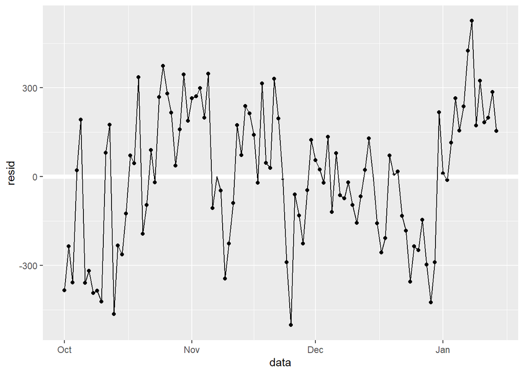

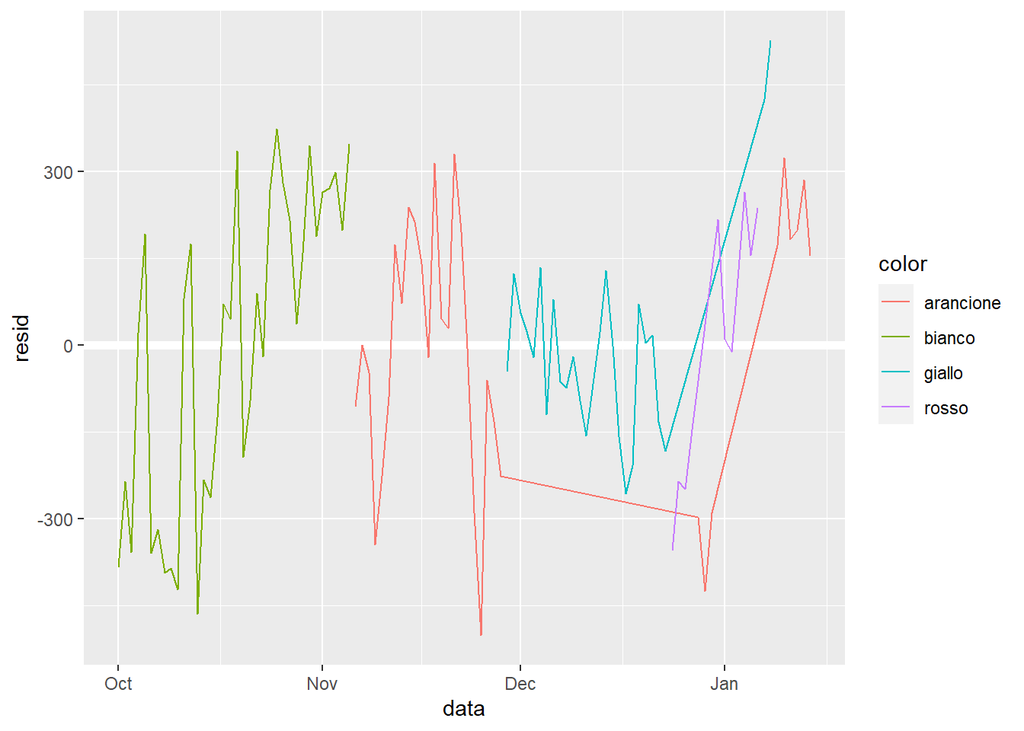

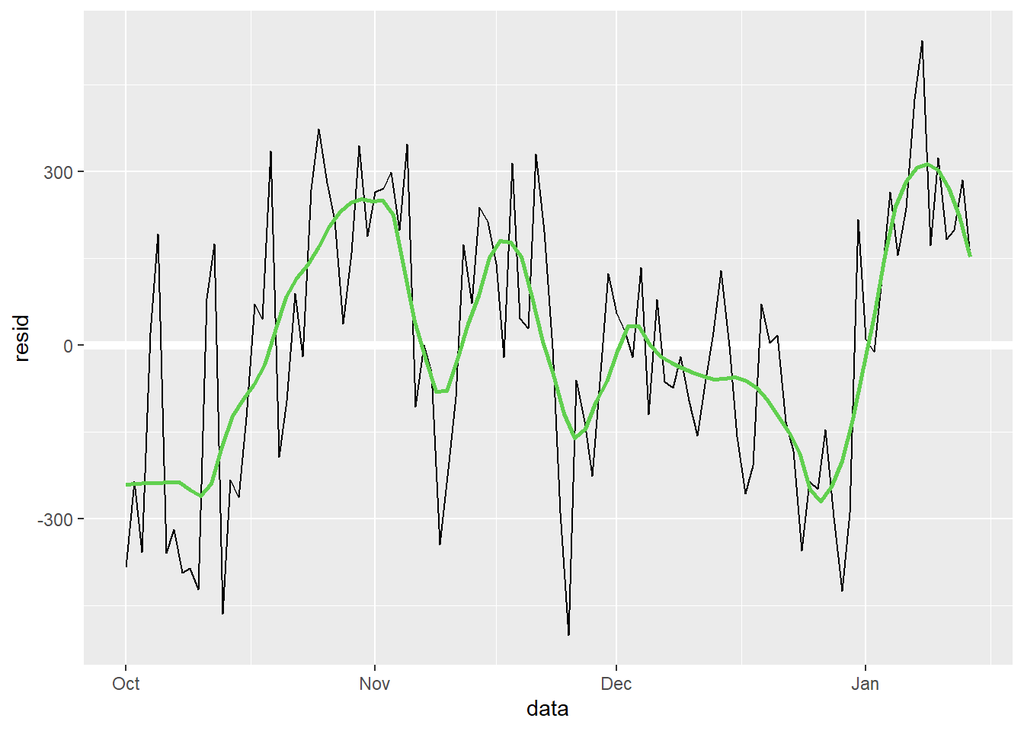

Now investigate the relationship with the highest correlated variable (which is given by people hospitalized with symptoms, maybe because the highest the number of people hospitalized, the higher the contagiousness and as a consequence the higher the number of new positives).

```
##
## Call:
## lm(formula = nuovi_positivi ~ ricoverati_con_sintomi, data = df)
##
## Residuals:
##     Min      1Q  Median      3Q     Max
## -613.48 -203.60  -32.51  172.74  660.66
##
## Coefficients:
##                         Estimate Std. Error t value Pr(>|t|)
## (Intercept)            -65.98155   78.67169  -0.839    0.403
## ricoverati_con_sintomi   1.00243    0.06681  15.005   <2e-16 ***
## ---
## Signif. codes:  0 '***' 0.001 '**' 0.01 '*' 0.05 '.' 0.1 ' ' 1
##
## Residual standard error: 287.3 on 121 degrees of freedom
## Multiple R-squared:  0.6504, Adjusted R-squared:  0.6476
## F-statistic: 225.2 on 1 and 121 DF,  p-value: < 2.2e-16
```

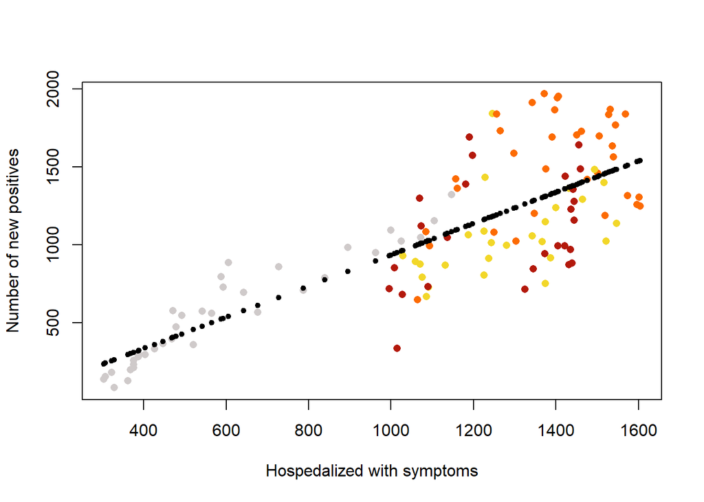

```
##
## Call:
## lm(formula = nuovi_positivi ~ ricoverati_con_sintomi + color,
##     data = df)
##
## Residuals:
##     Min      1Q  Median      3Q     Max
## -526.53 -141.60  -11.68  141.83  814.03
##
## Coefficients:
##                         Estimate Std. Error t value Pr(>|t|)
## (Intercept)              81.7438   173.1061   0.472    0.638
## ricoverati_con_sintomi    1.0289     0.1199   8.585 4.31e-14 ***
## colorbianco            -129.1461   114.0665  -1.132    0.260
## colorgiallo            -335.8289    67.2963  -4.990 2.10e-06 ***
## colorrosso             -310.7610    68.0731  -4.565 1.23e-05 ***
## ---
## Signif. codes:  0 '***' 0.001 '**' 0.01 '*' 0.05 '.' 0.1 ' ' 1
##
## Residual standard error: 255.6 on 118 degrees of freedom
## Multiple R-squared:  0.7303, Adjusted R-squared:  0.7211
## F-statistic: 79.87 on 4 and 118 DF,  p-value: < 2.2e-16
```

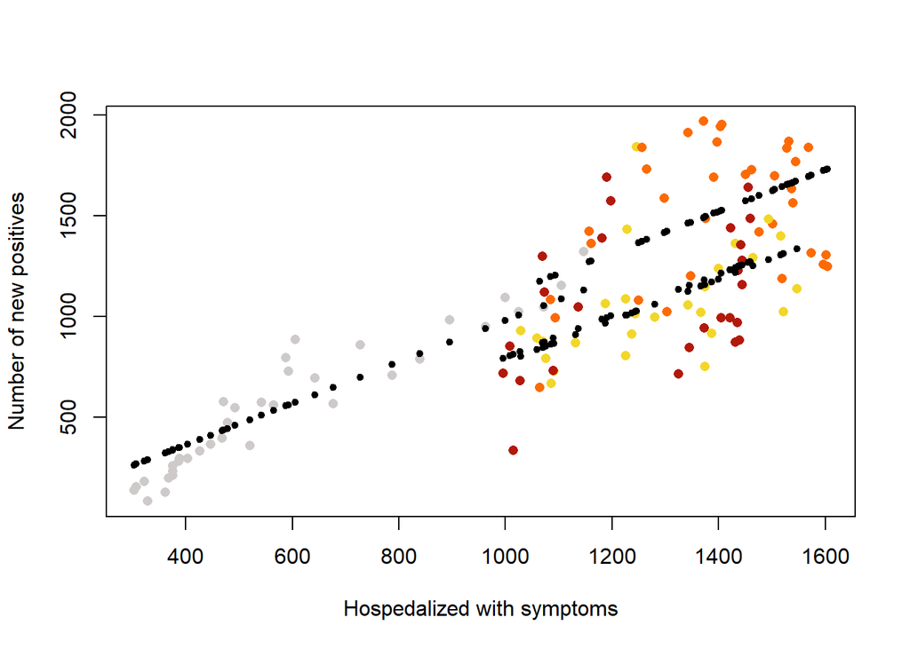

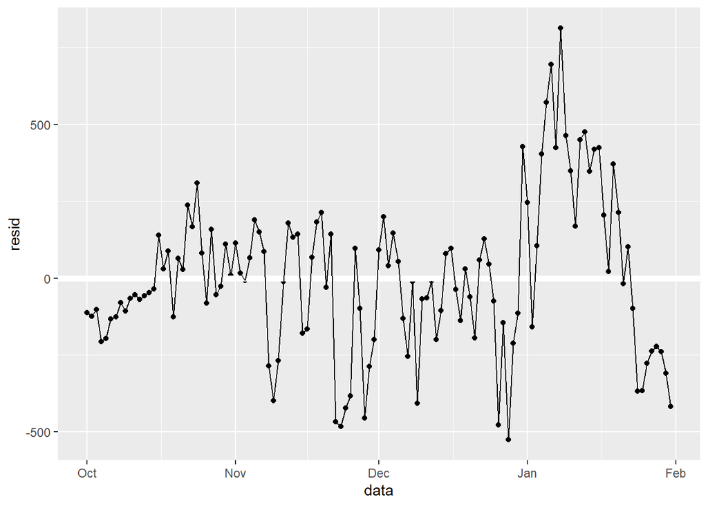

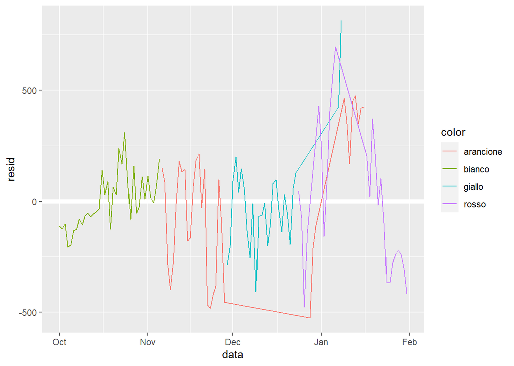

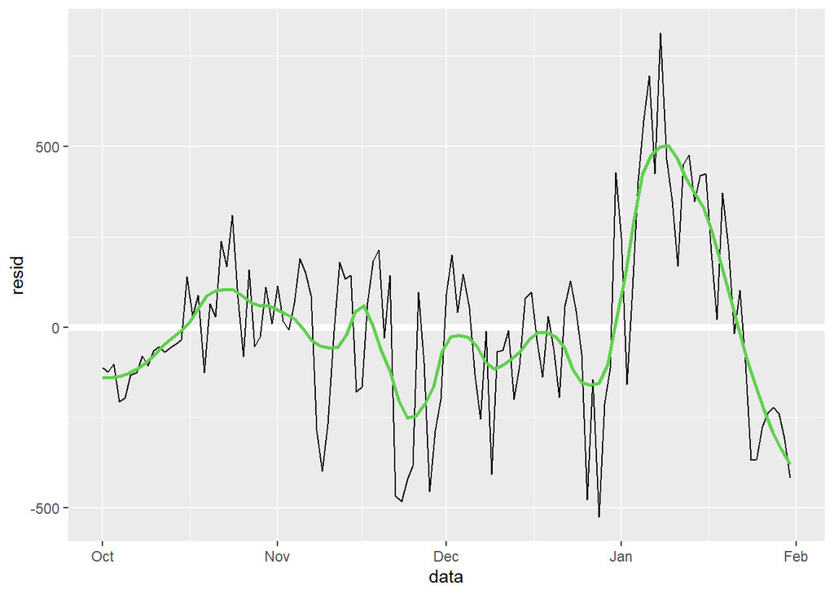